# Default Bayes Factor

17th September, 2019

## Joint work with

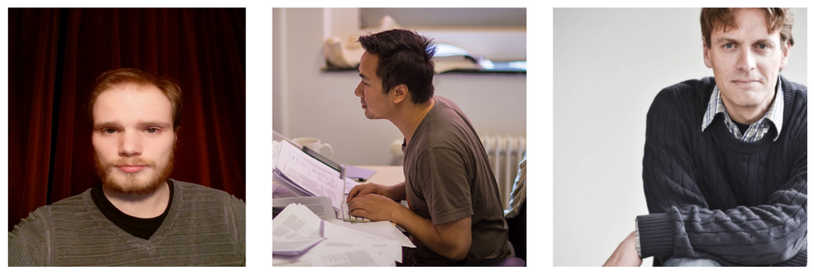

Don van den Bergh, Alexander Ly, Eric-Jan Wagenmakers

## The Second Moment’s First Moment

- Upon closer inspection, many scientific questions from various fields concern variances
- **Economics & Archeology:**
  - Do products become more homogeneous with increased specialization? (Kvamme et al., 1996)
- **Legal Studies:**
  - Which interventions best reduce unwanted variability in civil damage awards? (Sasks et al., 1997)
- **Genetics:**
  - What are the genetic effects on the variance of quantitative traits? (Pare et al., 2010)
- **Psychology:**
  - Do males show higher variance on intelligence? (Johnson et al., 2008)
  - Do males show higher variance on personality traits? (Borkenau et al., 2013)
  - Does the variance of mathematical ability increase across school grades? (Aunola et al., 2004)

## Problem Setup

- Let group \(k\) consist of \(n_k\) observations \(\mathbf{x}_k = \{x_{k1}, \ldots, x_{kn_1}\}\). We assume that

\[ x_{ki} \overset{\tiny{\text{i.i.d.}}}{\sim} \mathcal{N}\left(\mu_k, \sigma^2_k\right) \enspace , \]

- for all \(k \in \{1, \ldots, K\}\) and \(i \in \{1, \ldots, n_k\}\)
- We restrict our focus to the \(K = 2\) case. Our aim is to test the hypotheses

\[ \begin{aligned} \mathcal{H}_0 &: \sigma^2_1 = \sigma^2_2 \\[.5em] \mathcal{H}_1 &: \sigma^2_1 \neq \sigma^2_2 \enspace . \end{aligned} \]

- Bayesian inference provides a *predictive* perspective
- We require models that instantiate these hypotheses and that make predictions
- Without priors, no predictions!

## Two Perspectives

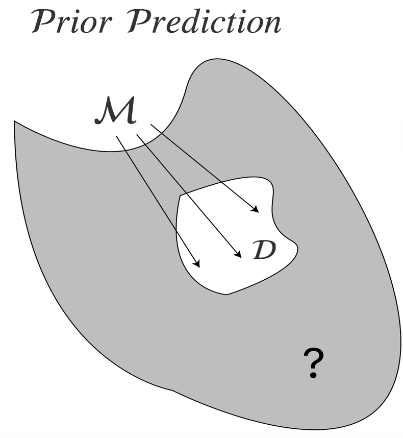

\[ p(\mathbf{y{}} \mid \mathcal{M}) = \int_{\Theta} p(\mathbf{y}\mid \theta, \mathcal{M}) \, p(\theta \mid \mathcal{M}) \, \mathrm{d}\theta \]

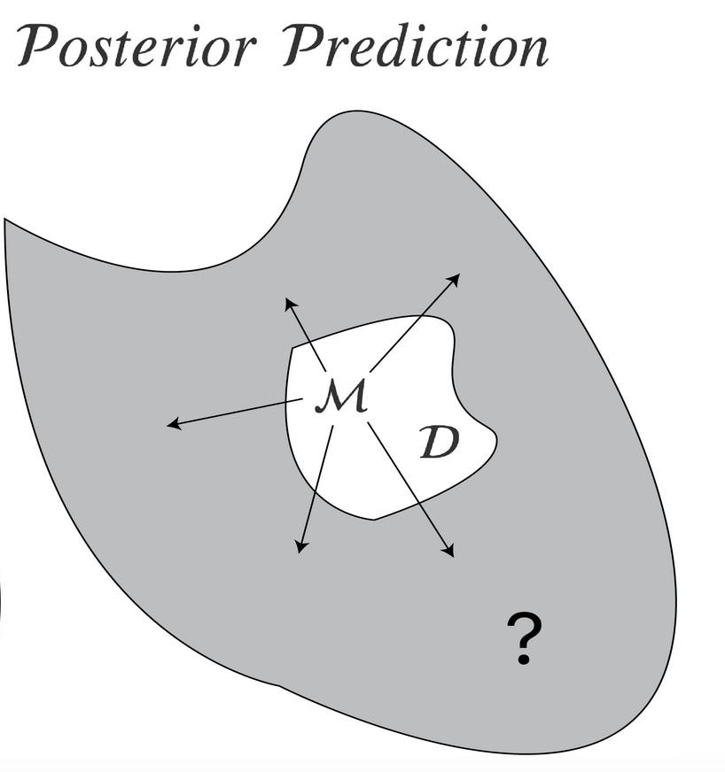

\[ \widehat{\text{elpd}}^{\mathcal{M}}_{\text{loo}} = \frac{1}{n} \sum_{i=1}^n \text{log}\int_{\Theta} p(\mathbf{y}_i \mid \mathbf{y}_{-i}, \theta) \, p(\theta \mid \mathbf{y}_{-i}) \, \mathrm{d}\theta \]

From https://fabiandablander.com/r/Law-of-Practice.html

## Bayes factor

- Let \(\mathbf{d} = (\mathbf{x}_1, \mathbf{x}_2)\)
- We focus here on the *prior predictive* perspective
- The ratio of two marginal likelihoods is called the Bayes factor
- Quantifies how much better one model predicts the data *compared to another* model

\[ \underbrace{\frac{p(\mathcal{M}_1 \mid \mathbf{d})}{p(\mathcal{M}_0 \mid \mathbf{d})}}_{\text{Posterior odds}} = \underbrace{\frac{p(\mathbf{d} \mid \mathcal{M}_1)}{p(\mathbf{d} \mid \mathcal{M}_0)}}_{\text{Bayes factor}} \hspace{.25em} \underbrace{\frac{p(\mathcal{M}_1)}{p( \mathcal{M}_0)}}_{\text{Prior odds}} \]

- We focus on the \(K = 2\) case and derive a *default* Bayes factor
- Next steps: Assigning priors to all parameters and integrating them out

## A Butchered Bayes factor

- Let \(\phi = (\mu_1, \mu_2)\) denote the *test-irrelevant* parameters
- Under \(\mathcal{H}_1\) we specify

\[ \begin{aligned} \pi(\phi) &\propto 1 \\[.5em] \pi(\sigma_1^2) &\sim \text{Inverse-Gamma}(\alpha, \beta) \\[.5em] \pi(\sigma_2^2) &\sim \text{Inverse-Gamma}(\alpha, \beta) \\[.5em] \end{aligned} \]

- Under \(\mathcal{H}_0\) we specify

\[ \begin{aligned} \pi(\phi) &\propto 1 \\[.5em] \pi(\sigma^2) &\sim \text{Inverse-Gamma}(\alpha, \beta) \end{aligned} \]

- where \(\sigma^2 = \sigma_1^2 = \sigma_2^2\)

## A Butchered Bayes factor

- The resulting Bayes factor is given by

\[ \begin{aligned} \text{BF}_{10} &= \frac{p(\mathbf{d} \mid \mathcal{M}_1)}{p(\mathbf{d} \mid \mathcal{M}_0)} \\[.5em] &= \frac{\int_{\sigma_1}\int_{\sigma_2}\int_{\phi} f(\mathbf{d} \mid \phi, \sigma_1, \sigma_2) \, \pi(\phi, \sigma_1, \sigma_2) \, \mathrm{d}\phi \, \mathrm{d}\sigma_1 \mathrm{d} \sigma_2}{\int_{\sigma}\int_{\phi}f(\mathbf{d} \mid \phi, \sigma) \, \pi(\phi, \sigma) \, \mathrm{d}\phi \, \mathrm{d}\sigma} \\[.5em] &= \frac{\frac{1}{2} \frac{\beta^\alpha}{\Gamma(\alpha)} \Gamma\left(\frac{n_1}{2} + \alpha\right) \Gamma\left(\frac{n_2}{2} + \alpha\right) \left(\beta + \frac{n_1 s_1^2}{2} \right)^{-\frac{n_1}{2} - \alpha} \left(\beta + \frac{n_2 s_2^2}{2} \right)^{-\frac{n_2}{2} - \alpha}}{\Gamma\left(\frac{n}{2} + \alpha\right) \left(\beta + \frac{n_1 s_1^2 + n_2 s_2^2}{2} \right)^{-\frac{n}{2} - \alpha}} \enspace , \end{aligned} \]

- where \(n = n_1 + n_2\) and \(n_k s_k = \sum_{i=1}^{n_k} (x_{ik} - \bar{x}_k)^2\)
- This Bayes factor is **not measurement invariant** nor **predictively matched**

## Principled Selection of Priors

- Select priors such that certain desiderata are fulfilled:
- **Measurement invariance:**
  - Bayes factor does not depend on the unit of measurements
- **Predictive matching:**
  - Bayes factor equals 1 for uninformative data
- **Model selection consistent:**
  - Bayes factor in favour of true model goes to \(\infty\) as \((n_1, n_2) \rightarrow \infty\)
- **Information consistent:**
  - Bayes factor in favour of true model goes to \(\infty\) as (finite) data provide infinite support
- **Limit consistent:**
  - If \(n_2\) fixed but \(n_1 \rightarrow \infty\), Bayes factor remains bounded
- We call the resulting Bayes factor a *default* Bayes factor (Jeffreys, 1961; Bayarri et al. 2012; Ly, 2018)

## Intuition behind Desiderata

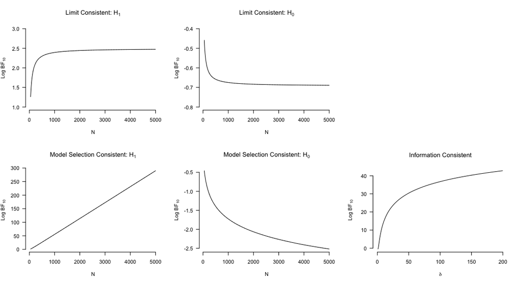

## Derivation of Default Bayes factor

- We borrow an idea from Jeffreys (1939) and write for \(\rho \in [0, 1]\)

\[ \begin{aligned} \sigma_1^2 &= \rho \sigma^2 \\[.5em] \sigma_2^2 &= (1 - \rho) \sigma^2 \end{aligned} \]

- such that \(\sigma_1^2 + \sigma_2^2 = \rho \sigma^2 + (1 - \rho)\sigma^2 = \sigma^2\)
- Observe that \(\rho = \frac{\sigma_1^2}{\sigma_1^2 + \sigma_2^2}\)
- We can rewrite the hypotheses know in terms of \(\rho\):

\[ \begin{aligned} \mathcal{H}_0 &: \rho = 0.50 \\[.5em] \mathcal{H}_1 &: \rho \neq 0.50 \end{aligned} \]

- This leads to \(p(\mathbf{y} \mid \mathcal{M}_0) = p(\mathbf{y} \mid \rho = 0.50, \mathcal{M}_1)\)

## Derivation of Default Bayes factor

- Let \(\phi = (\mu_1, \mu_2, \sigma)\) be the set of *test-irrelevant* parameters. Then

\[ \text{BF}_{10} = \frac{p(\mathbf{d} \mid \mathcal{M}_1)}{p(\mathbf{d} \mid \mathcal{M}_0)} = \frac{\int_{\rho} \int_{\phi} f(\mathbf{d} \mid \phi, \rho) \, \pi(\phi) \, \pi(\rho) \, \mathrm{d}\phi \, \mathrm{d}\rho}{\int_{\phi} f(\mathbf{d} \mid \phi, \rho = 0.50) \, \pi(\phi) \, \mathrm{d}\phi}\enspace . \]

- We can use improper priors \(\pi(\phi) = 1 \cdot 1 \cdot \sigma^{-1}\) because the normalizing constants cancel
- Key question: What prior do we assign the *test-relevant* parameter \(\rho\)?

## Prior on \(\rho\)

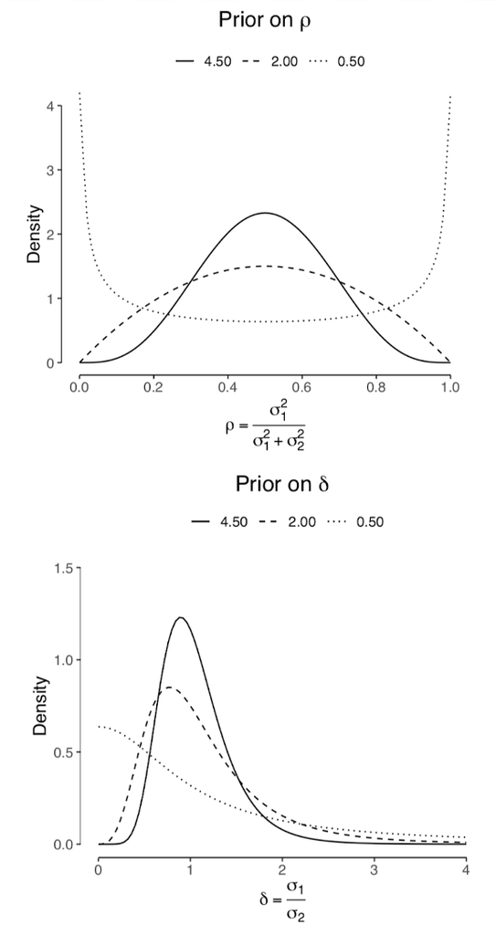

- Principled approach of choosing priors
  - Measurement invariance \(\checkmark\)
  - Predictive matching \(\checkmark\)
  - Model selection consistent \(\checkmark\)
  - Information consistent \(\checkmark\)
  - Limit consistent \(\checkmark\)
- A class of Beta priors fulfills these criteria

\[ \rho = \frac{\sigma_1^2}{\sigma_1^2 + \sigma_2^2} \sim \text{Beta}(\alpha, \alpha) \]

- This induces a Generalized Beta prime distribution on

\[ \delta \equiv \frac{\sigma_1}{\sigma_2} \sim \text{GeneralizedBetaPrime}(\alpha, 2, 1) \]

- \(\alpha = 4.50\) implies that \(p(\delta \in [0.50, 2]) = 0.95\)

## Result

- The Bayes factor in favour of \(\mathcal{H}_1\) is given by: \[ \text{BF}_{10} = \frac{\text{B}\left({\frac{n_2 - 1}{2} + \alpha},\ {\frac{n_1 - 1}{2} + \alpha}\right) \,_2F_1\left({\frac{n - 2}{2}};{\frac{n_2 - 1}{2} + \alpha};{\frac{n - 2}{2} + 2\alpha};{1 - \frac{n_2 s_2^2}{n_1 s_1^2}}\right)}{\text{B}\left({\alpha},\ {\alpha}\right) \left(1 + \frac{n_2 s_2^2}{n_1 s_1^2}\right)^{\frac{2 - n}{2}}} \]
- where \(n_k s_k^2 = \sum_{i=1}^{n_k} (x_{ik} - \bar{x}_{ik})^2\) and \(n = n_1 + n_2\)
- Note that the data only enter through the ratio \(\frac{n_2 s_2^2}{n_1 s_1^2}\)

## Example Application I

- Borkenau et al. (2013) study the variability in personality traits in four countries
- We re-analyze the Estonian sample: \(s_f^2 = 15.6\), \(s_m^2 = 19.9\), \(n_f = 969\), \(n_m = 716\)

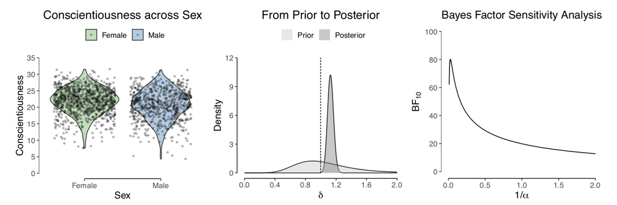

## Comparison with Fractional Bayes factor I

- There are alternative ways of specifying a prior distribution for testing
- One might sacrifice part of the data to specify minimally informative priors
  - *Partial* Bayes factors (O’Hagan, 1991)
  - *Intrinsic* Bayes factors (Berger & Pericchi, 1996)
  - *Fractional* Bayes factors (O’Hagan, 1995)
- Böing-Messing & Mulder (2018) propose an Automatic Fractional Bayes factor (AFBF) for testing hypotheses on variances
- It turns out that this is a special case of our Bayes factor with \(\alpha = 0.50\)

## Comparison with Fractional Bayes factor II

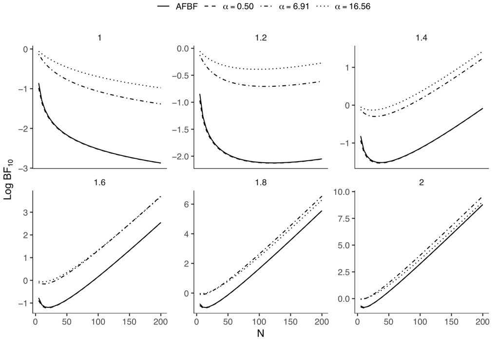

## Extension to \(K > 2\) groups

- We again write

\[ x_{ki} \overset{\tiny{\text{i.i.d.}}}{\sim} \mathcal{N}(\mu_k, \rho_k \sigma^2) \]

- for all \(k \in \{1, \ldots, K\}\) and \(i \in \{1, \ldots, n_k\}\) where \(\sum_{k=1}^K \rho_k = 1\)
- Standard \(\mathcal{H}_0\) and \(\mathcal{H}_1\) are

\[ \begin{align*} \mathcal{H}_0&: \rho_k = \frac{1}{k} \hspace{1em} \forall k \in \{1, \ldots, k\} \\ \mathcal{H}_1&: \mathbf{\rho} \sim \text{Dirichlet}(\alpha_1, \ldots, \alpha_k) \end{align*} \]

- However, we can flexibly test any hypotheses with mixed constraints such as

\[ \mathcal{H}_r: \rho_1 = \rho_2 > \rho_3, \rho_4, \rho_5 = \rho_6 > \rho_7 \]

- by constraining the prior and computing the marginal likelihood in Stan using bridgesampling (Meng & Wong, 1996; Gronau et al., 2017)

## Example Application II

- Aunola et al. (2004) find that the variance in mathematical ability increases across school grade
- We replicate this finding using large-scale data from MathGarden (\(n = 41801\))

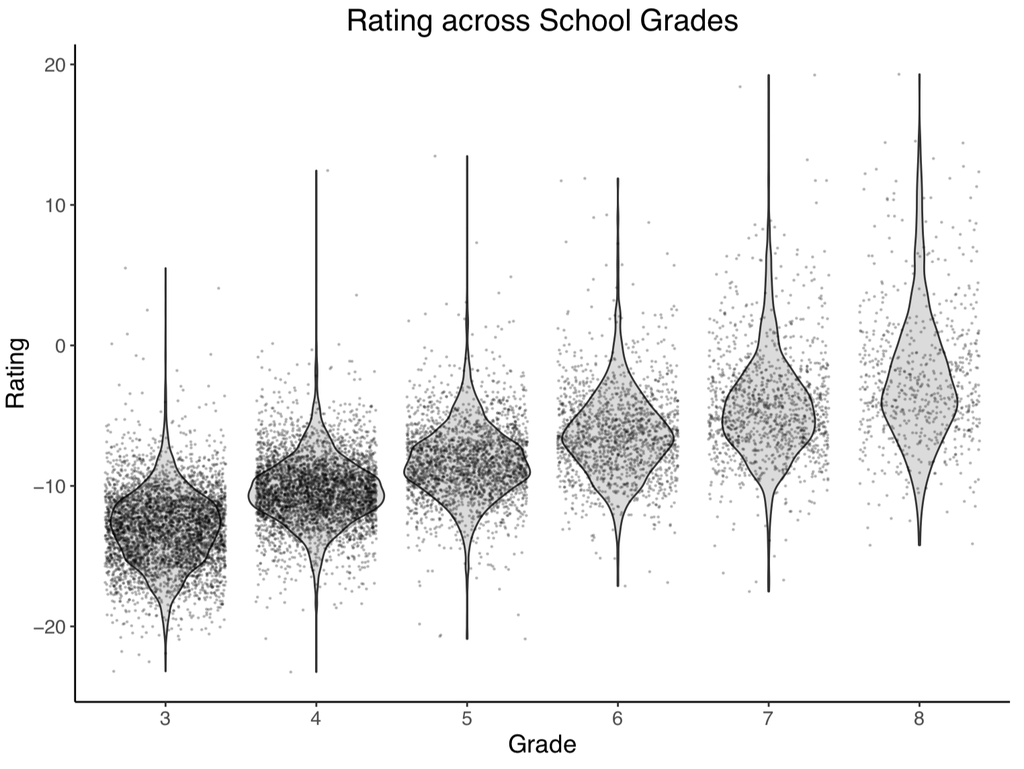

\[ \begin{align*} \mathcal{H}_0&: \rho_i = \rho_j \hspace{1em} \forall (i, j) \hspace{5em} p(\mathcal{M}_0 \mid y) = 0.00\\ \mathcal{H}_f&: \rho_i \neq \rho_j \hspace{1em} \forall (i, j) \hspace{5em} p(\mathcal{M}_f \mid y) = 0.00\\ \mathcal{H}_r&: \rho_i < \rho_j \hspace{1em} \forall (i < j) \hspace{4.25em} p(\mathcal{M}_r \mid y) = 1.00\\ \end{align*} \]

## Wrap-Up

- Many scientific questions from various fields concern variances
- Derived a *default* Bayes factor for the \(K = 2\) case
  - Fulfills a number of desiderata
  - Limit consistency yields \(K = 1\) group Bayes factor
  - Can extend point null hypothesis to a null-region
- Extended it to \(K > 2\) groups
  - Compute marginal likelihood for mixed hypotheses using bridgesampling
- Generalizes the ‘automatic’ Bayes factor proposed by Böing-Messing & Mulder (2018)
  - Allows sensitivity analyses and incorporation of prior information

## Short Advertisement

- You can find me online [@fdabl](https://twitter.com/fdabl) and fabiandablander.com where I write about
  - Love affairs and linear differential equations
  - Spurious correlations and random walks
  - Bayesian modeling in Stan: A case study
  - …

Thank you for your attention!

## Literature

- Kvamme, K. L., Stark, M. T., & Longacre, W. A. (1996). Alternative procedures for assessing standardization in ceramic assemblages. *American Antiquity, 61*(1), 116-126.
- Saks, M. J., Hollinger, L. A., Wissler, R. L., Evans, D. L., & Hart, A. J. (1997). Reducing variability in civil jury awards. *Law and Human Behavior, 21*(3), 243-256.
- Paré, G., Cook, N. R., Ridker, P. M., & Chasman, D. I. (2010). On the use of variance per genotype as a tool to identify quantitative trait interaction effects: a report from the Women’s Genome Health Study. *PLoS Genetics, 6*(6), e1000981.
- Johnson, W., Carothers, A., & Deary, I. J. (2008). Sex differences in variability in general intelligence: A new look at the old question. *Perspectives on Psychological Science, 3*(6), 518-531.
- Borkenau, P., Hřebíčková, M., Kuppens, P., Realo, A., & Allik, J. (2013). Sex differences in variability in personality: A study in four samples. *Journal of Personality, 81*(1), 49-60.
- Aunola, K., Leskinen, E., Lerkkanen, M. K., & Nurmi, J. E. (2004). Developmental dynamics of math performance from preschool to grade 2. *Journal of Educational Psychology, 96*(4), 699-713.
- Jeffreys, H. (1939). *Theory of Probability (1rd Ed.)*. Oxford, UK: Oxford University Press.
- Jeffreys, H. (1961). *Theory of Probability (3rd Ed.)*. Oxford, UK: Oxford University Press.

## Literature

- Bayarri, M. J., Berger, J. O., Forte, A., & García-Donato, G. (2012). Criteria for Bayesian model choice with application to variable selection. *The Annals of Statistics, 40*(3), 1550-1577.
- Ly, A. (2018). *Bayes factors for research workers*. Unpublished PhD Thesis
- O’Hagan, A. (1991). Discussion on posterior Bayes factors (by M. Aitkin). *Journal of the Royal Statistical Society: Series B (Methodological), 53*, 136.
- O’Hagan, A. (1995). Fractional Bayes factors for model comparison. *Journal of the Royal Statistical Society: Series B (Methodological), 57*(1), 99-118.
- Berger, J. O., & Pericchi, L. R. (1996). The intrinsic Bayes factor for model selection and prediction. *Journal of the American Statistical Association, 91(433)*, 109-122.
- Böing-Messing, F., & Mulder, J. (2018). Automatic Bayes factors for testing equality-and inequality-constrained hypotheses on variances. *Psychometrika, 83*(3), 586-617.
- Meng, X. L., & Wong, W. H. (1996). Simulating ratios of normalizing constants via a simple identity: a theoretical exploration. *Statistica Sinica, 6*(4), 831-860.
- Gronau, Q. F., Sarafoglou, A., Matzke, D., Ly, A., Boehm, U., Marsman, M., … & Steingroever, H. (2017). A tutorial on bridge sampling. *Journal of Mathematical Psychology, 81*, 80-97.